# Trabajo Final DiplomaCSC - Opción 2

## Carga de librerías a utilizar

```r
install.packages("textstem")
```

```
Error in install.packages : Updating loaded packages
```

## Etapa 1: carga de datos y preprocesamiento

El archivo que se adjunta consiste en un corpus de unas 7.000 noticias scrapeadas entre julio y septiembre de 2019 de los siguientes medios de circulación nacional:

Constituye una muestra aleatoria del corpus construido por Florencia Piñeyrúa para su tesina de grado “Procesamiento del lenguaje natural aplicado al estudio de tópicos de noticias de seguridad en Argentina: julio a septiembre 2019”. Una exposición más concentrada de sus resultados puede encontrarse en el siguiente artículo.

El corpus contiene, las siguientes variables:

id : identificador de cada documento

url : link a la noticia original

fecha : fecha de publicación

anio : año de publicación

mes : mes de publicación

dia : dia de publicación

medio : medio en el que fue publicado

orientacion: clasificación -provisoria- de los medios según su línea editorial predominante (más conservador, más progresista, neutral)

titulo

texto

### Carga dataset

```r
corpus_base <- read_csv("M5_corpus_medios.csv")
```

```r
# En este apartado vemos cuantas noticias aporta cada medio al corpus y calculamos la proporción sobre el total

corpus_base %>%
        group_by(medio) %>%
        summarise(n=n()) %>%
        mutate(
                total = sum(n),
                prop = n/total*100
                ) %>%
        ungroup() %>%
        select(medio, n, prop) %>%
        arrange(desc(n))
```

| medio | n | prop |
| --- | --- | --- |
| perfil | 1553 | 22.185714 |
| clarin | 1541 | 22.014286 |
| pagina12 | 949 | 13.557143 |
| lanacion | 883 | 12.614286 |
| infobae | 709 | 10.128571 |
| cronica | 609 | 8.700000 |
| minutouno | 418 | 5.971429 |
| telam | 338 | 4.828571 |

```r
     #   pivot_wider(names_from = medio, values_from = prop)
```

### Normalización y tokenización

```r
corpus_tidy <- corpus_base %>%
    mutate(texto= stringi::stri_trans_general(texto, "Latin-ASCII"),
         titulo = stringi::stri_trans_general(titulo, "Latin-ASCII")) %>%
    mutate(texto = str_replace_all(texto, '[[:digit:]]+', '')) %>%
    unnest_tokens(word, texto, to_lower = TRUE)

# En este este código tomamos el corpus de texto "corpus_base", lo normalizamos convirtiendo el texto y el título a caracteres ASCII, eliminamos los dígitos del texto y finalmente los dividimos en tokens para su posterior análisis.
```

### Eliminar stopwords

```r
corpus_tidy <- corpus_tidy %>%
  anti_join(stop_words_full)
```

*Nota -> en el archivo de stopwords agregué la palabra “embed” porque vi que aparecía en el top10 de minutouno y debe referir a algo de la página web. Si ves alguna otra palabra para quitar, la agregamos en esa línea de “tibble”*

### Corrección “años”

*Nota –> Agus acá pensé que como la palabra año/años aparece mucho y no pudimos lematizar, la juntemos en una sola. Ahora se me ocurre que podríamos eliminar esta palabra como stopword, porque qué aporta? aparece mucho probablemente hablando de fechas. Que opinás?*

```r
corpus_tidy <- corpus_tidy %>%
  mutate(word = case_when(
    word == 'ano' ~ 'anio',
    word == 'anos' ~ 'anio',
    TRUE ~ word
  ))
```

*Nota –> Probé y tampoco logré que funcione la lematización. Volvería sobre este punto más adelante*

```r
# PROBÉ UN MONTÓN DE ALTERNATIVAS, PERO EL CÓDIGO DE LA LEMATIZACIÓN SIGUE SIN FUNCIONAR (FIJATE QUE EL ELEMENTO CORPUS_TIDY_LEMM DUPLICA LAS MIMAS PALABRAS EN LA ÚLTIMA COLUMNA). ENTIENDO QUE PUEDE SER UN TEMA DEL DICCIONARIO QUE SE USA, PERO CON OTRAS OPCIONES TAMPOCO ME FUNCIONA
corpus_tidy_lemm <- corpus_tidy %>%
  mutate(word_lemmatized = lemmatize_words(word, language = "es"))



corpus_tidy_lemm %>%
  filter(word != word_lemmatized) %>%
  select(word, word_lemmatized)
```

## Etapa 2: Consignas

¿Cuáles son las palabras más utilizadas en cada uno de los medios? ¿Pueden verse diferencias? (Tener en cuenta las diferentes métricas trabajadas en el curso: tf, tf-idf, etc.) Generar las visualizaciones que considere más pertinentes para responder la pregunta

### Exploración palabras más frecuentes

```r
corpus_tidy %>%
        group_by(word, medio) %>%
        summarise(n=n()) %>%
        arrange(desc(n))

# Mediante este código agrupamos las palabras únicas en el corpus, contamos el número de ocurrencias de cada palabra y las ordenamos en función de su frecuencia de aparición, mostrando primero las palabras más frecuentes.

corpus_tidy %>%
  filter(medio == 'infobae')  %>%
  group_by(word) %>%
  summarise(n=n()) %>%
  arrange(desc(n))


# Mirada rápida a las palabras más frecuentes de algunos medios

corpus_tidy %>%
        group_by(medio, word) %>%
        summarise(n=n()) %>%
        arrange(desc(n)) %>%
        pivot_wider(names_from = medio,
                    values_from = n)

# Este código calcula el recuento de ocurrencias de cada palabra en el corpus de texto agrupado según el medio de comunicación, y luego reorganiza estos resultados en un formato más ancho donde cada medio tiene sus recuentos de ocurrencias asociados para cada palabra.
```

[output not shown]

```r
word_counts_10 <- corpus_tidy %>%
        group_by(medio, word) %>%
        summarise(n=n()) %>%
        slice_max(n, n = 10) %>%
        ungroup()
# En este paso calculamos el recuento de ocurrencias de cada palabra en el corpus, agrupadas por la columna "medio", y almacena estos recuentos en un nuevo dataframe llamado "word_counts" para pasarle a la función de graficado

word_counts_all_10 <- corpus_tidy %>%
        group_by(word) %>%
        summarise(n=n()) %>%
        slice_max(n, n = 10) %>%
        ungroup() %>%
        mutate(medio = 'general')

# Aquí calculamos el recuento de ocurrencias de cada palabra en el corpus, sin agrupar por medio. Luego, seleccionamos las 10 palabras más comunes en todo el corpus. A estos resultados les agregamos la etiqueta "general" en la columna "medio" para poder comparar visualmente la distribución general con la distribución por medio

word_counts_top_10 <- word_counts_10 %>%
  bind_rows(word_counts_all_10)

# Unifico en un dataset
```

*Nota -> me acordé de haber visto en alguna clase una función para crear varios gráficos de una. Con ayuda del chat llegué a esto, en la parte de “grafico” con el código de ggplot podemos jugar con los colores y demás cuestiones de formato*

```r
crear_graf_word_freq <- function(data) {
  medios <- unique(data$medio)
  graficos <- list()

  for (medio_actual in medios) {
    datos_medio <- data %>%
      filter(medio == medio_actual) %>%
      mutate(word = fct_reorder(word, n))

    grafico <- ggplot(datos_medio, aes(n, word)) +
                geom_col() +
                geom_text(aes(label = n), position = position_stack(vjust = 0.5), family = "Courier", color = "white") +
                labs(title = medio_actual,
                     x = "Frecuencia",
                     y = "Palabra") +
                theme_classic()+
                theme(plot.title = element_text(hjust= 0.5),
                      axis.title = element_blank(),
                      axis.ticks.x = element_blank(),
                      text = element_text(family = "Courier"))

    graficos[[medio_actual]] <- grafico
  }

  wrap_plots(graficos)
}

# Esta función crea para cada medio un gráfico con el top 10 de palabras más frecuentes
```

```r
crear_graf_word_freq(word_counts_top_10)

# Este código genera una visualización de las palabras más comunes en el corpus, desglosadas por medio y en general. Las palabras más comunes se muestran en orden descendente de frecuencia en cada categoría.
```

[output not shown]

### Term Frequency - TF:

*Nota -> Creo que toda esta parte se puede hacer más fácil sacando directamente el tf después de usar la función bind_tf_idf, pero así lo habíamos hecho en clase y queda calculado manualmente. Podemos ver si dejarlo o no.*

```r
words_tidy <- words_tidy %>%
  left_join(total_words) %>%
  ungroup() %>%
  arrange(desc(n))
```

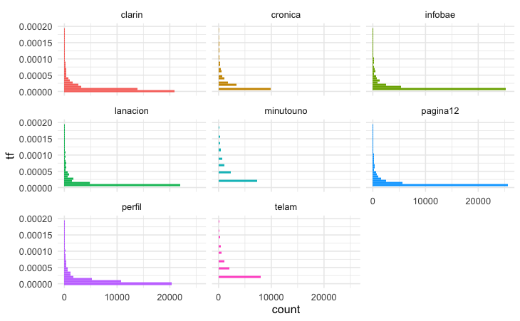

```r
words_tidy %>% mutate(tf = n/total) %>%
        ggplot(aes(tf, fill = medio)) +
                geom_histogram(show.legend = FALSE) +
                coord_flip()+
                xlim(NA, 0.0002) +
                facet_wrap(~medio) +
                theme_minimal()
```

Vemos que para los medios más masivos se cumple la Ley de Zipf: pocas palabras ocurren muchas veces. Los corpus de Crónica, Minuto Uno y Télam tienen menos términos que los demás y la tf tiene un rango menor (uso de palabras mejor distribuido).